# fastStructure

Harly Durbin

# Notes & questions

## Dataset key

- Which samples

| Name | Description | n | k ran |
| --- | --- | --- | --- |
| full | All species. All available samples. | 2,291 | 1-20 |
| 20all | All species. Up to 20 (ranked by coverage) samples per population label. | 886 | 1-20 |
| 5regionall | All species. Up to 5 (ranked by coverage) samples per species per region | 142 | 1-20 |
| 20cattle | Bos taurus, B.indicus, B. primigenius, composite. Up to 20 (ranked by coverage) samples per population label. | 768 | 1-20 |
| 5cattle | Bos taurus, B.indicus, B. primigenius, composite. Up to 5 (ranked by coverage) samples per population label. | 392 | 1-20 |
| allyak | B. grunniens and B. mutus. All available samples. | 231 | 1-10 |
| allgayalgaur | B. frontalis and B. gaurus. All available samples. | 24 | 1-10 |
| allbanteng | B. javanicus. All available samples. | 8 | 1-8 |

- Thinning parameter

[output not shown]

# Full datasets

- As expected, indicine/taurine ancestry in gayal and banteng ancestry in some East Asian indicine/composite + low levels of East Asian taurine <–> yak introgression

## `20all.onepercent`

- Model complexity that maximizes marginal likelihood = 4
- Model components used to explain structure in data = 6

### K = 4

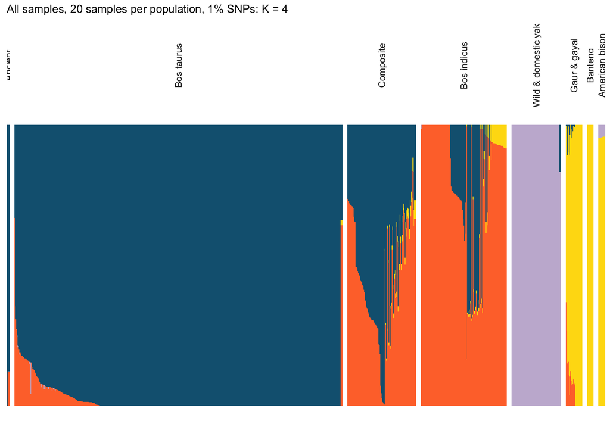

### K = 5

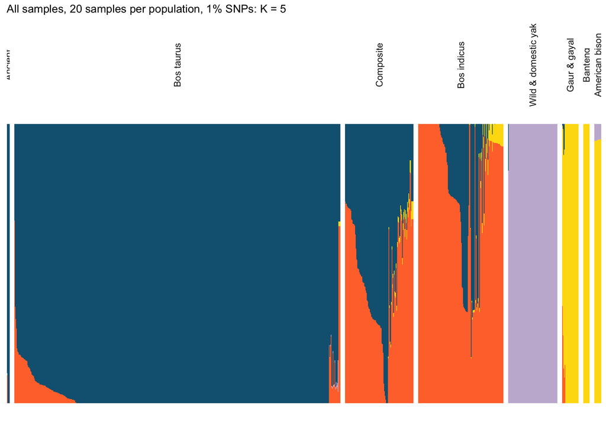

### K = 6

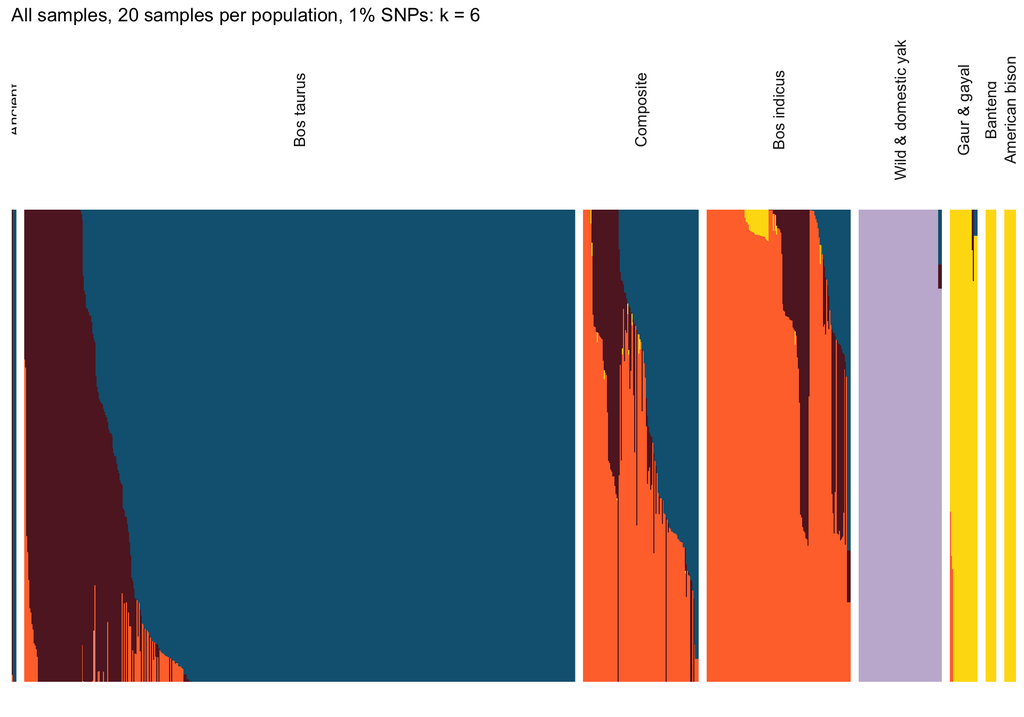

```r
read_structure(dataset_thinning = "20all.onepercent", k = 6) %>%
  filter(variable == "X2") %>%
  filter(value != 0)
```

| international_id | population | region | continent | species | variable | value |
| --- | --- | --- | --- | --- | --- | --- |
| UMCUSAU000000205018 | East African Zebu | East Africa | Africa | Bos indicus | X2 | 0.000001 |

- Maybe interestingly, the Siberian auroch and non-European (particularly African & Asian steppe) taurines create their own component here (in maroon above)

```r
read_structure(dataset_thinning = "20all.onepercent", k = 6) %>%
  filter(variable == "X3") %>%
  filter(value != 0) %>%
  arrange(desc(value), continent, region, population) %>%
  select(variable, value, everything())
```

| variable | value | international_id | population | region | continent | species |
| --- | --- | --- | --- | --- | --- | --- |
| X3 | 1.000000 | UMCUSAU000000199684 | Eastern Finncattle | Scandinavia | Europe | Bos taurus |
| X3 | 1.000000 | UMCUSAU000000202602 | Lagune | West Africa | Africa | Bos taurus |
| X3 | 1.000000 | UMCUSAU000000198375 | Muturu | West Africa | Africa | Bos taurus |
| X3 | 1.000000 | UMCUSAU000000198376 | Muturu | West Africa | Africa | Bos taurus |
| X3 | 1.000000 | UMCUSAU000000198377 | Muturu | West Africa | Africa | Bos taurus |
| X3 | 1.000000 | UMCUSAU000000198378 | Muturu | West Africa | Africa | Bos taurus |
| X3 | 1.000000 | UMCUSAU000000198381 | Muturu | West Africa | Africa | Bos taurus |
| X3 | 1.000000 | UMCUSAU000000198382 | Muturu | West Africa | Africa | Bos taurus |
| X3 | 1.000000 | UMCUSAU000000198383 | Muturu | West Africa | Africa | Bos taurus |
| X3 | 1.000000 | UMCUSAF000000033749 | N'dama | West Africa | Africa | Bos taurus |

[output cut: 258 more lines]

## `5regionall`

- Model complexity that maximizes marginal likelihood = 7
- Model components used to explain structure in data = 5

### K = 5

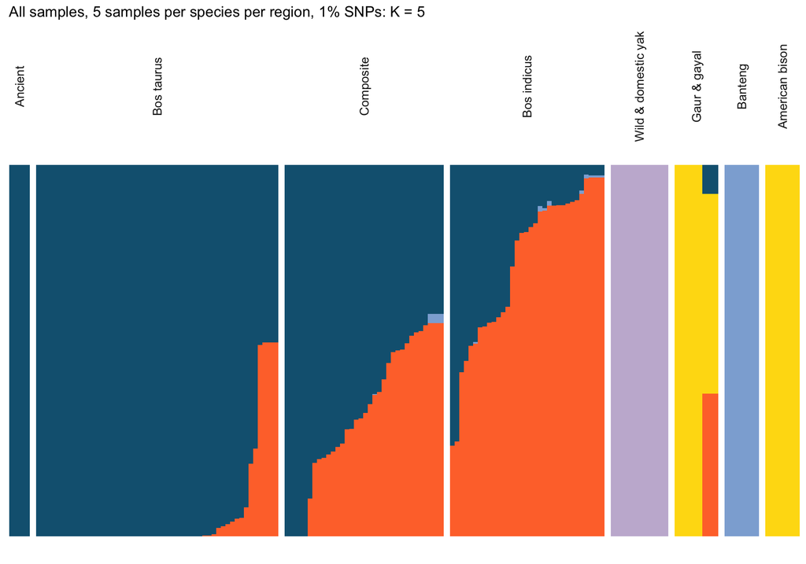

### K = 6

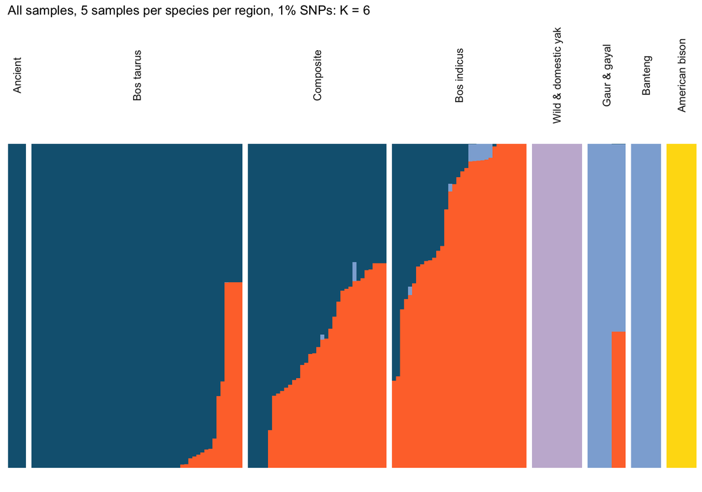

- Only 5 components actually used

### K = 7

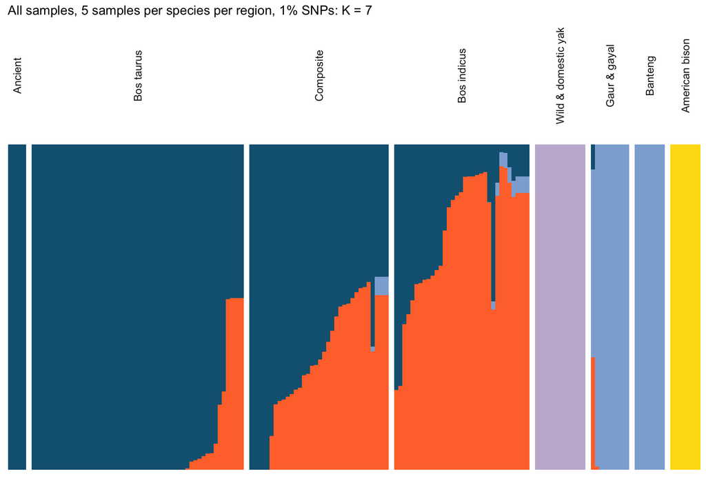

- Again, only 5 components actually used

# Cattle datasets

## `20cattle.onepercent`

- Model complexity that maximizes marginal likelihood = 3
- Model components used to explain structure in data = 6

### K = 2

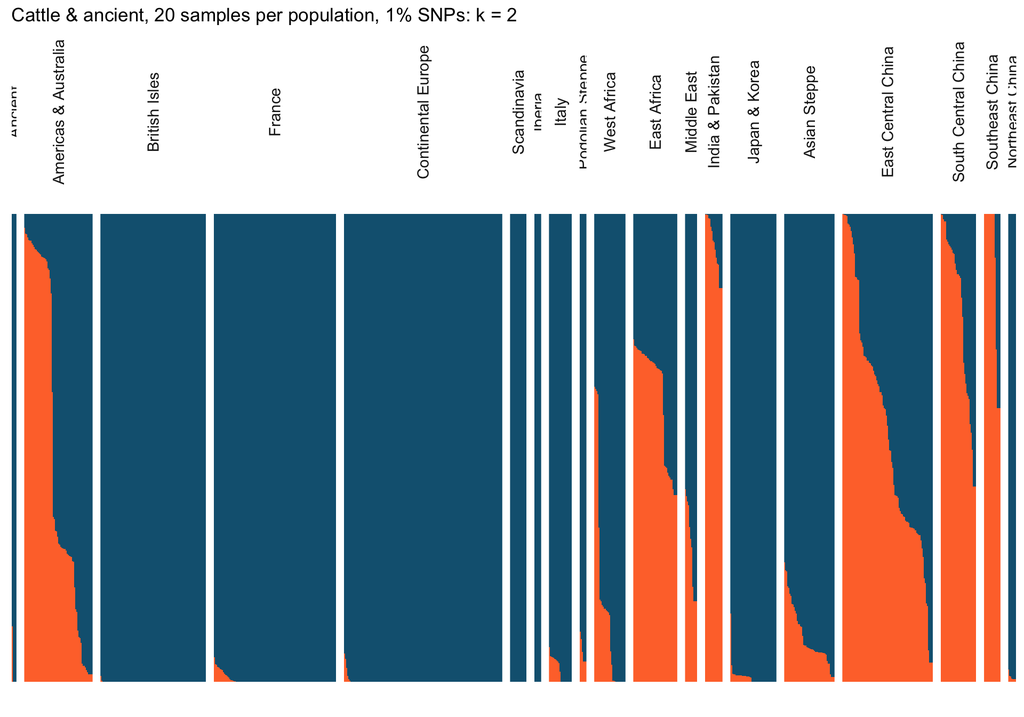

- Find indicine ancestry in expected European breeds (Italian/Podolian breeds; Charolais) plus a few continental European individuals whose breeds have open herdbooks in the U.S.

| variable | value | international_id | population | region | continent | species |
| --- | --- | --- | --- | --- | --- | --- |
| X2 | 0.107496 | UMCUSAF000000199746 | Maremmana | Podolian Steppe | Europe | Bos taurus |
| X2 | 0.091460 | UMCUSAU000000202601 | Sikias | Podolian Steppe | Europe | Bos taurus |
| X2 | 0.074508 | UMCUSAU000000204940 | Romagnola | Italy | Europe | Bos taurus |
| X2 | 0.064136 | UMCUSAF000000199745 | Podolica | Podolian Steppe | Europe | Bos taurus |
| X2 | 0.060481 | UMCUSAM000000200161 | Simmental | Continental Europe | Europe | Bos taurus |
| X2 | 0.055557 | UMCUSAU000000204938 | Romagnola | Italy | Europe | Bos taurus |
| X2 | 0.053875 | UMCUSAU000000198098 | Romagnola | Italy | Europe | Bos taurus |
| X2 | 0.052922 | UMCUSAM000000033844 | Romagnola | Italy | Europe | Bos taurus |
| X2 | 0.052340 | CHAUSAM000VPM122718 | Charolais | France | Europe | Bos taurus |
| X2 | 0.051171 | UMCUSAU000000194177 | Romagnola | Italy | Europe | Bos taurus |

[output cut: 24 more lines]

### K = 3

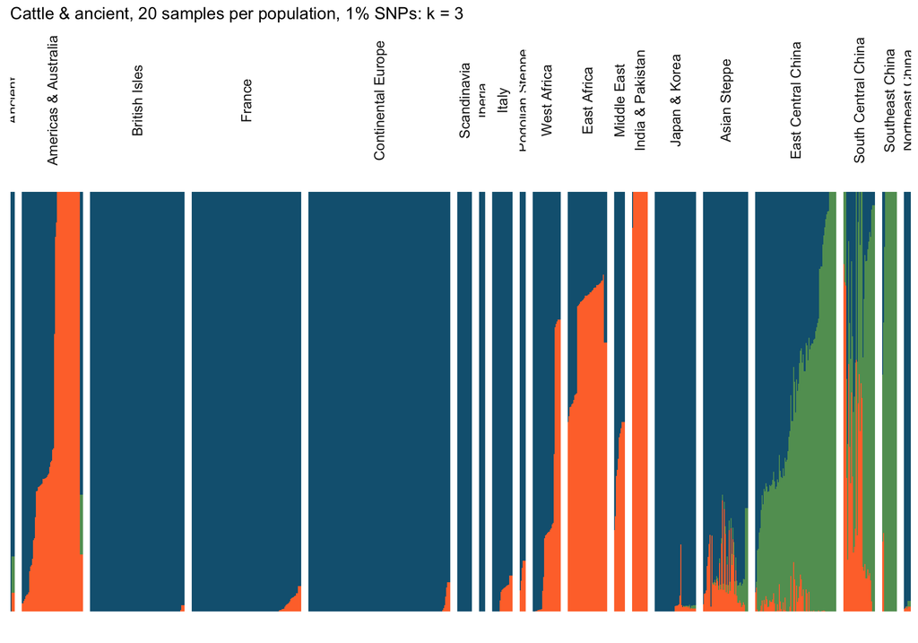

- New green component separates out East Asian indicines from Indian indicines

| variable | value | international_id | population | region | continent | species |
| --- | --- | --- | --- | --- | --- | --- |
| X1 | 1.000000 | UMCUSAU000000194489 | Wannan | East Central China | Asia | Bos indicus |
| X1 | 1.000000 | UMCUSAM000000198366 | Jian | Southeast China | Asia | Bos indicus |
| X1 | 1.000000 | UMCUSAF000000198373 | Leiqiong | Southeast China | Asia | Bos indicus |
| X1 | 1.000000 | UMCUSAU000000194493 | Leiqiong | Southeast China | Asia | Bos indicus |
| X1 | 1.000000 | UMCUSAU000000204743 | Leiqiong | Southeast China | Asia | Bos indicus |
| X1 | 0.999999 | UMCUSAM000000198358 | Wannan | East Central China | Asia | Bos indicus |
| X1 | 0.999999 | UMCUSAM000000198399 | Wannan | East Central China | Asia | Bos indicus |
| X1 | 0.999999 | UMCUSAU000000194487 | Wannan | East Central China | Asia | Bos indicus |
| X1 | 0.999999 | UMCUSAM000000198368 | Jian | Southeast China | Asia | Bos indicus |
| X1 | 0.999999 | UMCUSAM000000198369 | Jian | Southeast China | Asia | Bos indicus |

[output cut: 172 more lines]

### K = 4

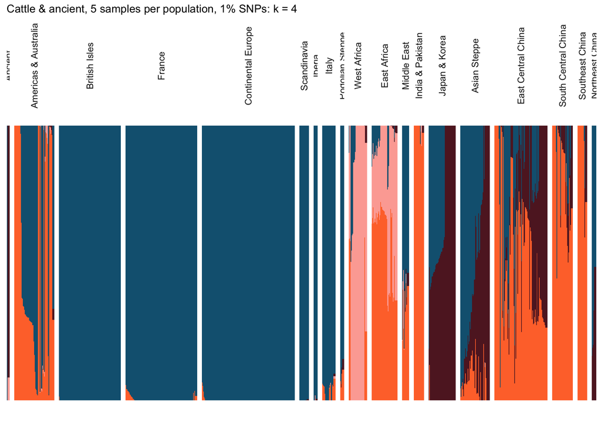

- Pink component separates out African taurines AND maroon component separates out Asian taurines

### K = 5

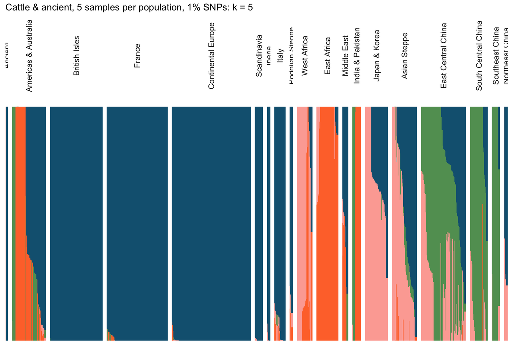

- Last component probably associated with technical error: only two (very different) individuals with > 0 % assignment

```r
read_structure(dataset_thinning = "20cattle.onepercent", k = 5) %>%
  arrange(variable, desc(value)) %>%
  filter(variable == "X4") %>%
  filter(value > 0) %>%
  select(variable, value, everything())
```

| variable | value | international_id | population | region | continent | species |
| --- | --- | --- | --- | --- | --- | --- |
| X4 | 0.020981 | UMCUSAM000000198317 | Tibetan | Asian Steppe | Asia | Bos taurus |
| X4 | 0.000001 | UMCUSAU000000205018 | East African Zebu | East Africa | Africa | Bos indicus |

- East Asian indicine in green (I think this is pretty noisy though - some Brahmans, which derive from Indian indicine breeds, get assigned completely to the East Asian indicine cluster)
- Non-European taurines in pink

### K = 6

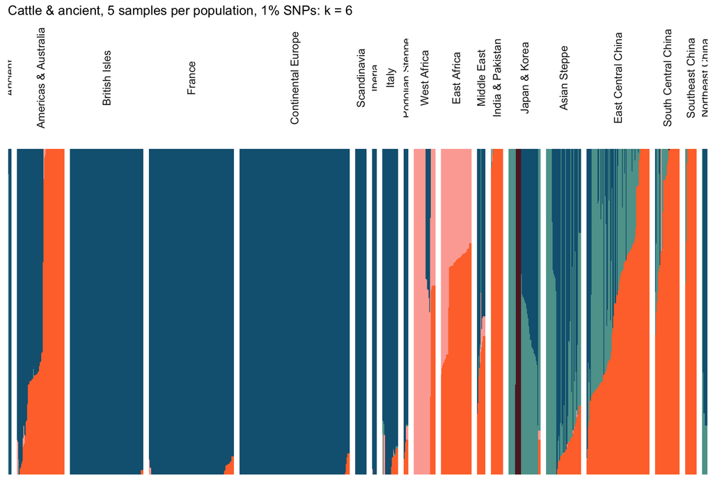

- Some low-lying African taurine and Indian indicine shows up in several American Criollo breeds. This makes sense considering they derive from Spanish cattle which mixed with Brahman type cattle in America

| inferred_source | value | population | international_id | region | continent | species | variable |
| --- | --- | --- | --- | --- | --- | --- | --- |
| European taurine | 0.893764 | Limonero | UMCUSAU000000194533 | Americas & Australia | Americas & Australia | Bos taurus | X3 |
| African taurine | 0.106235 | Limonero | UMCUSAU000000194533 | Americas & Australia | Americas & Australia | Bos taurus | X4 |
| European taurine | 0.899793 | Limonero | UMCUSAU000000194529 | Americas & Australia | Americas & Australia | Bos taurus | X3 |
| African taurine | 0.100207 | Limonero | UMCUSAU000000194529 | Americas & Australia | Americas & Australia | Bos taurus | X4 |
| European taurine | 0.952511 | Corriente | UMCUSAU000000194434 | Americas & Australia | Americas & Australia | Bos taurus | X3 |
| Asian taurine | 0.047489 | Corriente | UMCUSAU000000194434 | Americas & Australia | Americas & Australia | Bos taurus | X6 |
| European taurine | 0.999999 | Limonero | UMCUSAU000000194532 | Americas & Australia | Americas & Australia | Bos taurus | X3 |
| European taurine | 0.981475 | Corriente | UMCUSAU000000194431 | Americas & Australia | Americas & Australia | Bos taurus | X3 |
| Indian indicine | 0.018525 | Corriente | UMCUSAU000000194431 | Americas & Australia | Americas & Australia | Bos taurus | X1 |
| European taurine | 0.977191 | San Martinero | UMCUSAM000000198523 | Americas & Australia | Americas & Australia | Bos taurus | X3 |

[output cut: 20 more lines]

- Again, African taurines form their own cluster (pink)

```r
read_structure(dataset_thinning = "20cattle.onepercent", k = 6) %>%
  arrange(variable, desc(value)) %>%
  filter(variable == "X4") %>%
  filter(value > 0) %>%
  select(variable, value, everything())
```

| variable | value | international_id | population | region | continent | species |
| --- | --- | --- | --- | --- | --- | --- |
| X4 | 1.000000 | UMCUSAU000000198375 | Muturu | West Africa | Africa | Bos taurus |
| X4 | 1.000000 | UMCUSAU000000143398 | N'dama | West Africa | Africa | Bos taurus |
| X4 | 1.000000 | UMCUSAU000000143399 | N'dama | West Africa | Africa | Bos taurus |
| X4 | 1.000000 | UMCUSAU000000143400 | N'dama | West Africa | Africa | Bos taurus |
| X4 | 1.000000 | UMCUSAU000000143401 | N'dama | West Africa | Africa | Bos taurus |
| X4 | 1.000000 | UMCUSAU000000143402 | N'dama | West Africa | Africa | Bos taurus |
| X4 | 1.000000 | UMCUSAU000000143403 | N'dama | West Africa | Africa | Bos taurus |
| X4 | 1.000000 | UMCUSAU000000143404 | N'dama | West Africa | Africa | Bos taurus |
| X4 | 1.000000 | UMCUSAU000000143405 | N'dama | West Africa | Africa | Bos taurus |
| X4 | 1.000000 | UMCUSAU000000143406 | N'dama | West Africa | Africa | Bos taurus |

[output cut: 95 more lines]

- The two trypanotolerant breeds (N’dama and Muturu) assign completely to this cluster while other African taurine breeds assign to both African and European taurine clusters

```r
read_structure(dataset_thinning = "20cattle.onepercent", k = 6) %>%
  filter(species == "Bos taurus" & continent == "Africa") %>%
  mutate(inferred_source = case_when(
    variable == "X1" ~ "Indian indicine",
    variable == "X3" ~ "European taurine",
    variable == "X4" ~ "African taurine",
    variable == "X5" ~ "Mishima",
    variable == "X6" ~ "Asian taurine"
  )) %>%
  select(inferred_source, value, population, everything()) %>%
  arrange(international_id, desc(value)) %>%
  filter(value != 0)
```

| inferred_source | value | population | international_id | region | continent | species | variable |
| --- | --- | --- | --- | --- | --- | --- | --- |
| African taurine | 0.999999 | Muturu | UMCUSAU000000198376 | West Africa | Africa | Bos taurus | X4 |
| African taurine | 0.999999 | Muturu | UMCUSAU000000198378 | West Africa | Africa | Bos taurus | X4 |
| African taurine | 0.999999 | Muturu | UMCUSAU000000198381 | West Africa | Africa | Bos taurus | X4 |
| African taurine | 0.999999 | Muturu | UMCUSAU000000198382 | West Africa | Africa | Bos taurus | X4 |
| African taurine | 0.999999 | Muturu | UMCUSAU000000198383 | West Africa | Africa | Bos taurus | X4 |
| African taurine | 1.000000 | N'dama | UMCUSAU000000143398 | West Africa | Africa | Bos taurus | X4 |
| African taurine | 1.000000 | N'dama | UMCUSAU000000143399 | West Africa | Africa | Bos taurus | X4 |
| African taurine | 1.000000 | N'dama | UMCUSAU000000143400 | West Africa | Africa | Bos taurus | X4 |
| African taurine | 1.000000 | N'dama | UMCUSAU000000143401 | West Africa | Africa | Bos taurus | X4 |
| African taurine | 1.000000 | N'dama | UMCUSAU000000143402 | West Africa | Africa | Bos taurus | X4 |

[output cut: 23 more lines]

- Some Asian taurines and indicines in blue-green

```r
read_structure(dataset_thinning = "20cattle.onepercent", k = 6) %>%
  arrange(variable, desc(value)) %>%
  filter(variable == "X6") %>%
  filter(value > 0) %>%
  select(variable, value, everything())
```

| variable | value | international_id | population | region | continent | species |
| --- | --- | --- | --- | --- | --- | --- |
| X6 | 1.000000 | UMCUSAU000000198229 | Hanwoo | Japan & Korea | Asia | Bos taurus |
| X6 | 1.000000 | UMCUSAU000000198230 | Hanwoo | Japan & Korea | Asia | Bos taurus |
| X6 | 1.000000 | UMCUSAU000000198237 | Hanwoo | Japan & Korea | Asia | Bos taurus |
| X6 | 1.000000 | UMCUSAU000000198248 | Hanwoo | Japan & Korea | Asia | Bos taurus |
| X6 | 1.000000 | UMCUSAU000000198250 | Hanwoo | Japan & Korea | Asia | Bos taurus |
| X6 | 1.000000 | UMCUSAU000000198251 | Hanwoo | Japan & Korea | Asia | Bos taurus |
| X6 | 1.000000 | UMCUSAU000000198252 | Hanwoo | Japan & Korea | Asia | Bos taurus |
| X6 | 1.000000 | UMCUSAU000000198254 | Hanwoo | Japan & Korea | Asia | Bos taurus |
| X6 | 1.000000 | UMCUSAM000000198313 | Tibetan | Asian Steppe | Asia | Bos taurus |
| X6 | 1.000000 | UMCUSAM000000198316 | Tibetan | Asian Steppe | Asia | Bos taurus |

[output cut: 173 more lines]

```r
read_structure(dataset_thinning = "20cattle.onepercent", k = 6) %>%
  filter(species == "Bos indicus" & continent == "Africa") %>%
  mutate(inferred_source = case_when(
    variable == "X1" ~ "Indian indicine",
    variable == "X3" ~ "European taurine",
    variable == "X4" ~ "African taurine",
    variable == "X5" ~ "Mishima",
    variable == "X6" ~ "Asian taurine"
  )) %>%
  select(inferred_source, value, population, everything()) %>%
  arrange(international_id, desc(value)) %>%
  filter(value != 0)
```

| inferred_source | value | population | international_id | region | continent | species | variable |
| --- | --- | --- | --- | --- | --- | --- | --- |
| Indian indicine | 0.512887 | East African Zebu | UMCUSAU000000205018 | East Africa | Africa | Bos indicus | X1 |
| African taurine | 0.487109 | East African Zebu | UMCUSAU000000205018 | East Africa | Africa | Bos indicus | X4 |
| NA | 0.000001 | East African Zebu | UMCUSAU000000205018 | East Africa | Africa | Bos indicus | X2 |
| European taurine | 0.000001 | East African Zebu | UMCUSAU000000205018 | East Africa | Africa | Bos indicus | X3 |
| Mishima | 0.000001 | East African Zebu | UMCUSAU000000205018 | East Africa | Africa | Bos indicus | X5 |
| Asian taurine | 0.000001 | East African Zebu | UMCUSAU000000205018 | East Africa | Africa | Bos indicus | X6 |
| Indian indicine | 0.581113 | Gudali | UMCUSAU000000205013 | West Africa | Africa | Bos indicus | X1 |
| African taurine | 0.418886 | Gudali | UMCUSAU000000205013 | West Africa | Africa | Bos indicus | X4 |
| Indian indicine | 0.651926 | Kenana | UMCUSAU000000194308 | East Africa | Africa | Bos indicus | X1 |
| African taurine | 0.348073 | Kenana | UMCUSAU000000194308 | East Africa | Africa | Bos indicus | X4 |

[output cut: 35 more lines]

```r
read_structure(dataset_thinning = "20cattle.onepercent", k = 6) %>%
  arrange(variable, desc(value)) %>%
  filter(variable == "X5") %>%
  filter(value > 0) %>%
  select(variable, value, everything()) %>%
  left_join(sample_metadata %>%
              select(international_id, avg_coverage, owner))
```

| variable | value | international_id | population | region | continent | species | avg_coverage | owner |
| --- | --- | --- | --- | --- | --- | --- | --- | --- |
| X5 | 1.000000 | UMCUSAU000000194161 | Mishima | Japan & Korea | Asia | Bos taurus | 9.020345 | Department of Bioscience, Faculty of Applied Bioscience, Tokyo University of Agriculture |
| X5 | 1.000000 | UMCUSAU000000194165 | Mishima | Japan & Korea | Asia | Bos taurus | 9.133793 | Department of Bioscience, Faculty of Applied Bioscience, Tokyo University of Agriculture |
| X5 | 1.000000 | UMCUSAU000000194166 | Mishima | Japan & Korea | Asia | Bos taurus | 10.211724 | Department of Bioscience, Faculty of Applied Bioscience, Tokyo University of Agriculture |
| X5 | 0.999999 | UMCUSAU000000194163 | Mishima | Japan & Korea | Asia | Bos taurus | 9.355172 | Department of Bioscience, Faculty of Applied Bioscience, Tokyo University of Agriculture |
| X5 | 0.999999 | UMCUSAU000000194164 | Mishima | Japan & Korea | Asia | Bos taurus | 7.027931 | Department of Bioscience, Faculty of Applied Bioscience, Tokyo University of Agriculture |
| X5 | 0.999999 | UMCUSAU000000198260 | Mishima | Japan & Korea | Asia | Bos taurus | 5.754483 | Department of Bioscience, Faculty of Applied Bioscience, Tokyo University of Agriculture |
| X5 | 0.999999 | UMCUSAU000000198261 | Mishima | Japan & Korea | Asia | Bos taurus | 7.269310 | Department of Bioscience, Faculty of Applied Bioscience, Tokyo University of Agriculture |
| X5 | 0.276003 | UMCUSAU000000194162 | Mishima | Japan & Korea | Asia | Bos taurus | 8.800000 | Department of Bioscience, Faculty of Applied Bioscience, Tokyo University of Agriculture |
| X5 | 0.004325 | UMCUSAF000000198391 | Dianzhong | South Central China | Asia | Bos indicus | 7.899655 | Northwest A&F University |
| X5 | 0.002782 | UMCUSAU000000194540 | Mangshi Zebu | South Central China | Asia | Bos indicus | 6.097241 | Kunming Institute of Zoology, Chinese Academy of Sciences |

[output cut: 2 more lines]

- Last component almost certainly associated with technical error: only one individual with > 0 % assignment

```r
read_structure(dataset_thinning = "20cattle.onepercent", k = 6) %>%
  arrange(variable, desc(value)) %>%
  filter(variable == "X2") %>%
  filter(value > 0) %>%
  select(variable, value, everything())
```

| variable | value | international_id | population | region | continent | species |
| --- | --- | --- | --- | --- | --- | --- |
| X2 | 0.000001 | UMCUSAU000000205018 | East African Zebu | East Africa | Africa | Bos indicus |

## `5cattle.onepercent`

- Model complexity that maximizes marginal likelihood = 2
- Model components used to explain structure in data = 3

### K = 2

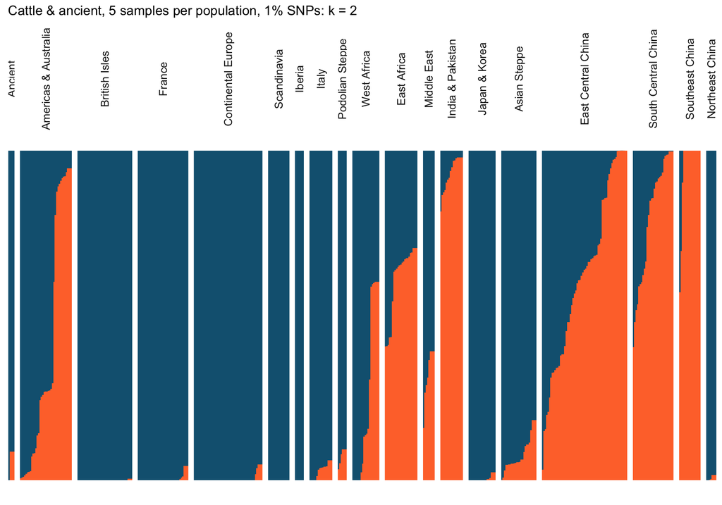

### K = 3

- Components appear to be taurines (dark blue) and indicines (orage)
  - Other component associated with Siberian auroch (light blue)

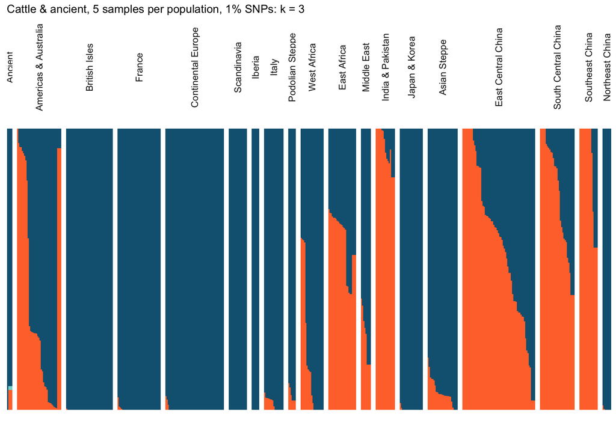

### K = 4

- First three components appear to be taurines (dark blue), Indian indicines (orange), and East Asian indicines (green)
  - Barely visible, but the 4th component separates out Derbyshire auroch (likely related to technical error; light blue)

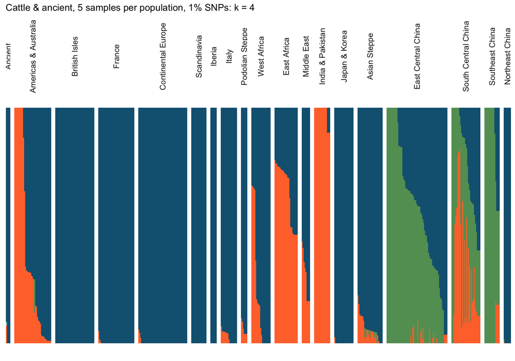

# Outgroup datasets

## `allyak.onepercent`

- Model complexity that maximizes marginal likelihood = 2
- Model components used to explain structure in data = 3

### K = 2

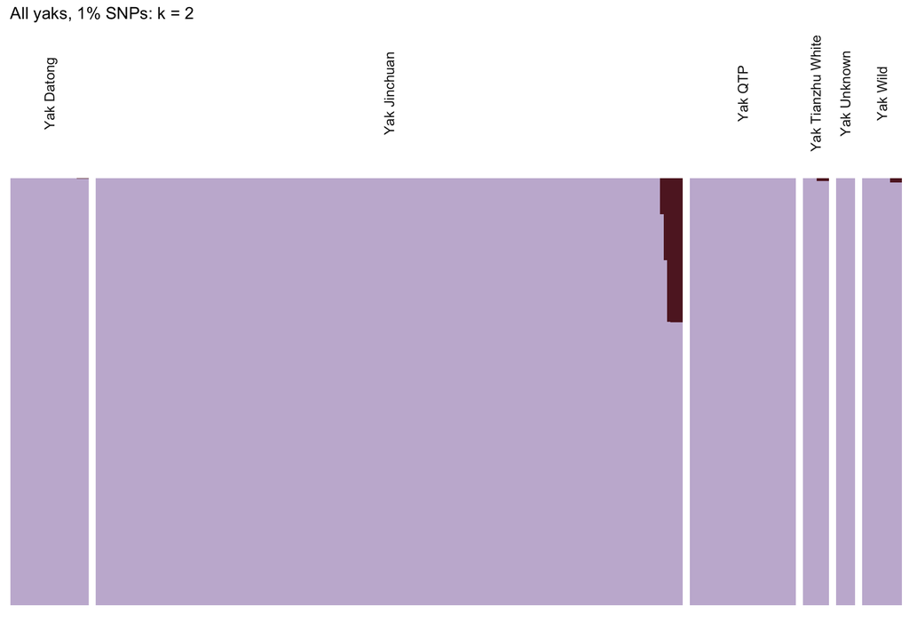

- Second cluster in Jinchuan yaks probably associated with technical error - all of them come from the same university

| international_id | population | region | continent | species | variable | value | owner | avg_coverage |
| --- | --- | --- | --- | --- | --- | --- | --- | --- |
| UMCUSAF000000202744 | Yak Jinchuan | Asian Steppe | Asia | Wild & domestic yak | X1 | 0.336805 | Southwest Minzu University | 8.896897 |
| UMCUSAM000000202672 | Yak Jinchuan | Asian Steppe | Asia | Wild & domestic yak | X1 | 0.335804 | Southwest Minzu University | 8.950345 |
| UMCUSAF000000202743 | Yak Jinchuan | Asian Steppe | Asia | Wild & domestic yak | X1 | 0.192038 | Southwest Minzu University | 9.994828 |
| UMCUSAF000000202742 | Yak Jinchuan | Asian Steppe | Asia | Wild & domestic yak | X1 | 0.084326 | Southwest Minzu University | 7.966897 |

### K = 3

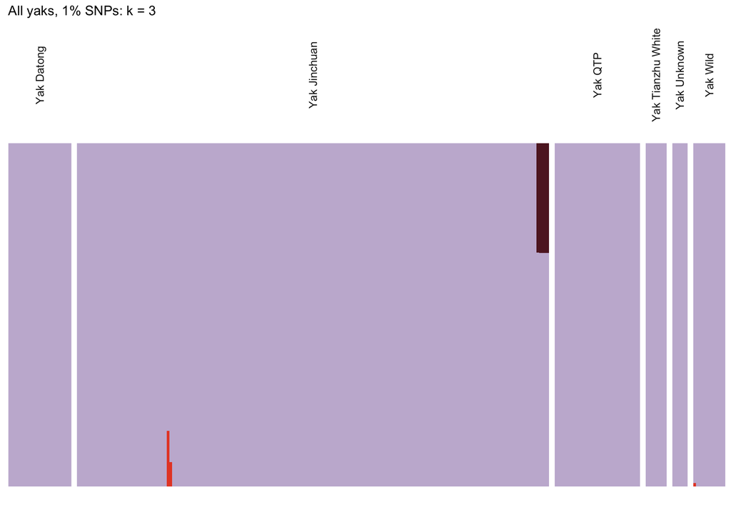

- Again, other 2 clusters likely technical error

| international_id | population | region | continent | species | variable | value | owner | avg_coverage |
| --- | --- | --- | --- | --- | --- | --- | --- | --- |
| UMCUSAM000000202672 | Yak Jinchuan | Asian Steppe | Asia | Wild & domestic yak | X1 | 0.319091 | Southwest Minzu University | 8.950345 |
| UMCUSAF000000202744 | Yak Jinchuan | Asian Steppe | Asia | Wild & domestic yak | X1 | 0.317971 | Southwest Minzu University | 8.896897 |
| UMCUSAF000000202743 | Yak Jinchuan | Asian Steppe | Asia | Wild & domestic yak | X3 | 0.162255 | Southwest Minzu University | 9.994828 |
| UMCUSAF000000202742 | Yak Jinchuan | Asian Steppe | Asia | Wild & domestic yak | X3 | 0.071196 | Southwest Minzu University | 7.966897 |

## `allgaurgayal.onepercent`

### K = 2

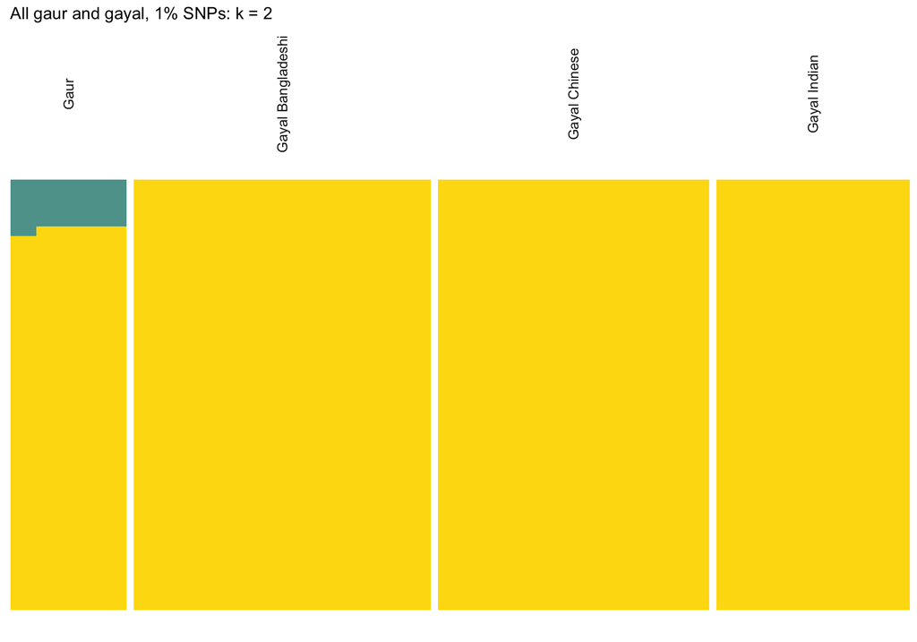

# Commentary

- Within cattle datasets, I think using 5 samples per population rather than 20 gives results that are more interpretable/less variable & noisy
- Within taurines
  - Non-European (African, Asian) taurines make up their own cluster in `20all.onepercent` K = 6 and `20cattle.onepercent` K = 5
- Within indicines
  - East Asian indicines often form their own component
- Something weird with Jinchuan yaks
- No evidence for structure within banteng